# One Microservice - A simulation in simmer

Patrick Boehnke

December 30, 2024

# 1 Introduction

We’re going to develop a simulation of a single microservice using [simmer](https://r-simmer.org/). The purpose is two fold:

1. I want to learn more about using simmer
2. I want to build towards a model that incorporates Bayesian statistics and discrete event simulation to understand the behavior of microservice based systems

## 1.1 simmer

I want to have a simulation where I can generate events (API requests) using arbitrary size and arrival time distributions while getting information about queue times and load. In looking for a software package that helps me with this simulation work, I had a few additional requirements:

1. I wanted something that integrates with R or Python because this whole project is developed in Posit Cloud
2. I need it to be somewhat performant because we will simulate large systems
3. Has to handle arbitrary size and arrival time distributions because API requests are anything but normal

Originally, I was going to use [SimPy](https://simpy.readthedocs.io/en/latest/) since it meets my requirements. However, at the time of this writing the Python support in Posit Cloud is in beta. So I kept looking until I found [simmer](https://r-simmer.org/), a discrete event simulation package for R. So let’s give it a go and learn how to use it together.

## 1.2 Ultimate modeling aim

The goal of this article is to start down a journey of simulating microservice performance and reliability by combining realistic workloads with first principles based simulations. We will start with one simple microservice (this article) and gradually build up a system of interacting services. We can then explore what controls performance and reliability as well as learning how to improve our design by incorporating resiliency patterns.

# 2 Defining terms for our simulation

1. Event - this is a single API request to the service to perform a discrete unit of work
2. Service - an entity that takes Events and processes them consisting of a Compute layer and a Data Storage layer
3. Resource - a concept in simmer used to represent the individual layers of each Service

# 3 Setup for simmer

## 3.1 Installation

Installing simmer is quite easy and instructions can be found [here](https://r-simmer.org/#installation)

## 3.2 Setup

To get started we will need to tell R to load simmer, set a random number generator seed, and start a simmer environment.

```r
library(simmer)
library(ggplot2)
library(dplyr)
set.seed(42)

env <- simmer("OneMicroService")
```

# 4 Writing our simulation

## 4.1 Trajectory for our service

Simmer defines actions/paths as trajectories. Our microservice will need a corresponding trajectory that encapsulates the compute layer and the data layer. Since we’re treating each component as a resource we will need to seize it, wait, and then release it. Here we call our compute layer ‘app’ and the data layer ‘database’.

```r
request <- trajectory("request path") %>%
  ## add a api hosting app
  seize("app", 1) %>%
  timeout(function() rnorm(1, 10)) %>%
  release("app", 1) %>%
  ## add a backing database
  seize("database", 1) %>%
  timeout(function() rnorm(1, 5)) %>%
  release("database", 1)
```

If you’re wondering about the timeout statement it just uses rnorm to generate the timeout value with mean 10 or 5 for the app and database resource, respectively. The standard deviation is not specified and defaults to 1. For more details about rnorm see [this helpful page](https://www.scaler.com/topics/r-rnorm/)

## 4.2 Adding resources and generators

Now that our trajectory is defined, we need to add the resources to the underlying environment. We are also going to add a generator that makes requests with random gaps sampled from a normal distribution specified by N(10,2).

```r
env %>%
  add_resource("app", capacity=1, queue_size = 20) %>%
  add_resource("database", capacity=1, queue_size = 20) %>%
  add_generator("request", request, function() rnorm(1, 10, 2))
```

```
## simmer environment: OneMicroService | now: 0 | next: 0
## { Monitor: in memory }
## { Resource: app | monitored: TRUE | server status: 0(1) | queue status: 0(20) }
## { Resource: database | monitored: TRUE | server status: 0(1) | queue status: 0(20) }
## { Source: request | monitored: 1 | n_generated: 0 }
```

## 4.3 Running our simmer simulation

```r
env %>% run(until = 40)
```

```
## simmer environment: OneMicroService | now: 40 | next: 40.5277373426487
## { Monitor: in memory }
## { Resource: app | monitored: TRUE | server status: 1(1) | queue status: 0(20) }
## { Resource: database | monitored: TRUE | server status: 1(1) | queue status: 0(20) }
## { Source: request | monitored: 1 | n_generated: 4 }
```

Based on our run duration and arrival time distribution we would expect approximately 4 API requests to be processed. This is likely not enough for a reliable simulation but let’s take a look at the results anyway.

## 4.4 Short simulation results

To get the full output we need to use the monitor functions in simmer:

```r
env %>% get_mon_arrivals() %>%
  transform(waiting_time = end_time - start_time - activity_time)
```

```
##       name start_time end_time activity_time finished replication waiting_time
## 1 request0   12.74192 27.99892        15.257     TRUE           1            0
```

This output shows us when the request started, the request ended, the request duration, and the request wait time. Since this table is a lot, let’s try out some graphs after we run the simulation a bit longer.

```r
env %>% run(until = 4000)
```

```
## simmer environment: OneMicroService | now: 4000 | next: 4001.78675659364
## { Monitor: in memory }
## { Resource: app | monitored: TRUE | server status: 1(1) | queue status: 6(20) }
## { Resource: database | monitored: TRUE | server status: 1(1) | queue status: 0(20) }
## { Source: request | monitored: 1 | n_generated: 402 }
```

First up is a histogram of request duration.

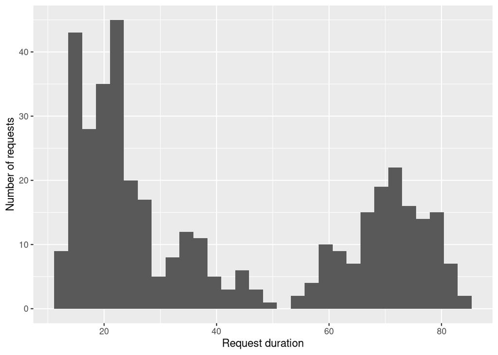

```r
env %>%
  get_mon_arrivals %>%
  ggplot(aes(end_time - start_time)) +
  geom_histogram() +
  xlab("Request duration") +
  ylab("Number of requests")
```

Now let’s look at resource usage

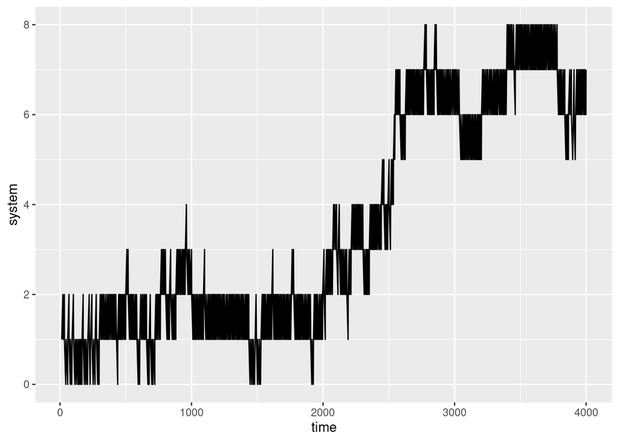

```r
get_mon_resources(env) -> mon_resource_output
as_tibble(mon_resource_output) %>% filter(resource=="app") -> app_output
ggplot(data=app_output) + geom_line(aes(x=time, y=system))
```

See that uptick at time 2000? That’s because we are putting too many events into the service and it gets bogged down and can never catch up again. To demonstrate this let’s rerun our simulation with a bigger gap between requests.

# 5 Rerunning with fewer requests

Since the code is the same I won’t show it again here and instead just show the plots

First plot of request durations:

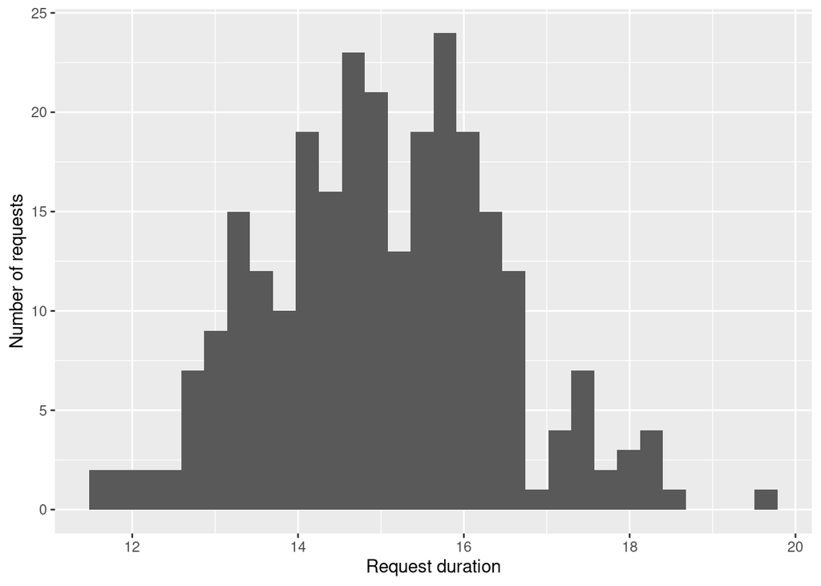

```r
env %>%
  get_mon_arrivals %>%
  ggplot(aes(end_time - start_time)) +
  geom_histogram() +
  xlab("Request duration") +
  ylab("Number of requests")
```

You can see that the second peak of slower requests is now gone. That’s because our service is less busy. Let’s look at how the resources are being used:

```r
get_mon_resources(env) -> mon_resource_output
as_tibble(mon_resource_output) %>% filter(resource=="app") -> app_output
app_output
```

```
## # A tibble: 531 × 9
##    resource  time server queue capacity queue_size system limit replication
##    <chr>    <dbl>  <int> <int>    <dbl>      <dbl>  <int> <dbl>       <int>
##  1 app       16.5      1     0        1         20      1    21           1
##  2 app       27.3      0     0        1         20      0    21           1
##  3 app       33.1      1     0        1         20      1    21           1
##  4 app       42.2      0     0        1         20      0    21           1
##  5 app       51.0      1     0        1         20      1    21           1
##  6 app       61.4      0     0        1         20      0    21           1
##  7 app       66.7      1     0        1         20      1    21           1
##  8 app       77.0      0     0        1         20      0    21           1
##  9 app       81.8      1     0        1         20      1    21           1
## 10 app       92.7      0     0        1         20      0    21           1
## # ℹ 521 more rows
```

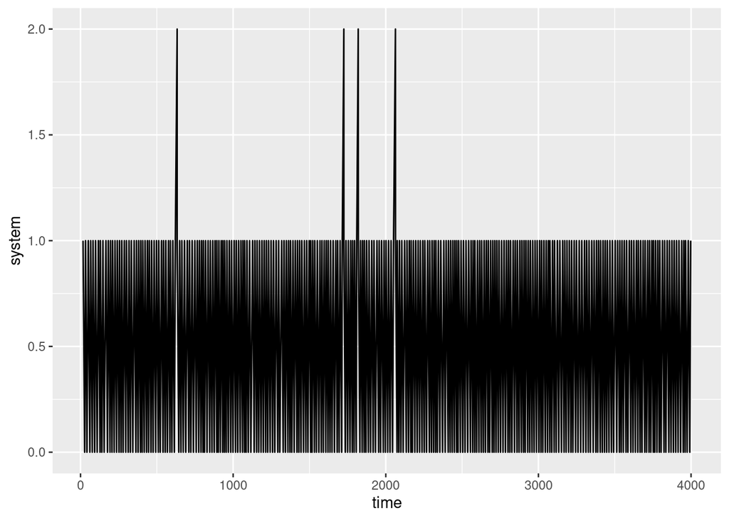

```r
ggplot(data=app_output) + geom_line(aes(x=time, y=system))
```

# 6 Summary

In this first article we implemented a simple microservice simulation in simmer and ran it to understand the behavior. We also saw what happened when our service got more requests than it can handle. In the next part we will build on our simulation by varying the load and examining the response times.

# 7 Computing Environment